# Regresión

Jordan Golubov y José Arévalo

2026-04-16

## Principios básicos sobre las variables

Existen dos tipos de variables y el tipo de análisis depende del tipo de variable que se esta midiendo:

1. Variables contínuas (velocidad, profunidad)
2. Variables discretas o categóricas (sexo, número de áfidos)

Por lo general queremos explicar un fenómeno en términos de otro.

1. ¿Cúal es el nivel de fósforo en diferentes lagos?
2. ¿Cúal es la diversidad entre sitios?
3. ¿El tamaño del individuo dice algo acerca de su potencial reproductivo?

En todos los casos anteriores estamos pensando en que una variables puede explicarse por otra variable. Entendemos entonces una variable dependiente y una variable independiente.

Antes de empezar necesitas saber varias cosas:

1. ¿Cúal de tu variable de respuesta?
2. ¿Cúal es tu variable explicatoria?
3. ¿Las variables explicatorias son contínuas, categóricas (discretas) o una combinación?
4. ¿Qué clase de variable de respuesta se tienen?. Es una medida contínua, un conteo, una proporción, un tiempo a la muerte, o una categoría?

## Selección de método estadístico según el tipo de variable:

| Tipo de variable | Estadístico |
| --- | --- |
| Todas las variables contínuas | Análsis de Regresión |
| Todas las variavles categóricas | Anális de varianza |
| Algunas variables contínuas y unas categóricas | Análsis de covarianza |

### La regresión

La regresión inicia con una hipótesis de causa y efecto: el valor de X causa directa o indirectamente el valor de la variable Y. En algunos casos la dirección es clara, como por ejemplo, el área de una isla controla el número de especies. En otras situaciones no es tan claro, por ejemplo, ¿Los depredadores controlan la abundancia de presas o las presas controlan la abundancia de depredadores?

Ya que se establece la relación causa efecto, el siguiente paso es asignarle una función matemática de como es esta relación. La función más sencilla es que `y` es una función líneal de `x` de tal manera que:

$$Y = β + mX$$

En otras palabras quiere decir que tomes un valor de la variable `x`, multiplícada por `m` y sumamos este número a $β$, el resultado es el valor de la variable `y`.

Esta función describe la ecuación de la recta y tiene dos paŕametros $β$ y $m$, tambien llamados la ordenada al orígen o intercepto y la pendiente, respectivamente. $β$ es el valor de la función cuando $x = 0$. La $m$ significa el cambio en la variable $y$ por cada unidad de cambio de la variable $X$.

## El ejemplo

Queremos saber el efecto que tiene la concentración de taninos sobre el crecimiento de un gusano. Si graficamos la concentración $x$ contra el crecimiento $y$, ya podemos generar una hipótesis.

Primero generamos nuestro conjunto de datos:

```r
Muestra <- c(1,2,3,4,5,6,7,8,9)
Crecimiento <- c(12,10,8,11,6,7,2,3,3)
Tanino <- c(0,1,2,3,4,5,6,7,8)
Gusanos <- data.frame(Muestra, Crecimiento,Tanino)
Gusanos
```

```
##   Muestra Crecimiento Tanino
## 1       1          12      0
## 2       2          10      1
## 3       3           8      2
## 4       4          11      3
## 5       5           6      4
## 6       6           7      5
## 7       7           2      6
## 8       8           3      7
## 9       9           3      8
```

Si graficamos las variables, Tanino, (`x`) y Crecimineto (`y`), podemos tener visualmente una idea de lo que esta sucediendo.

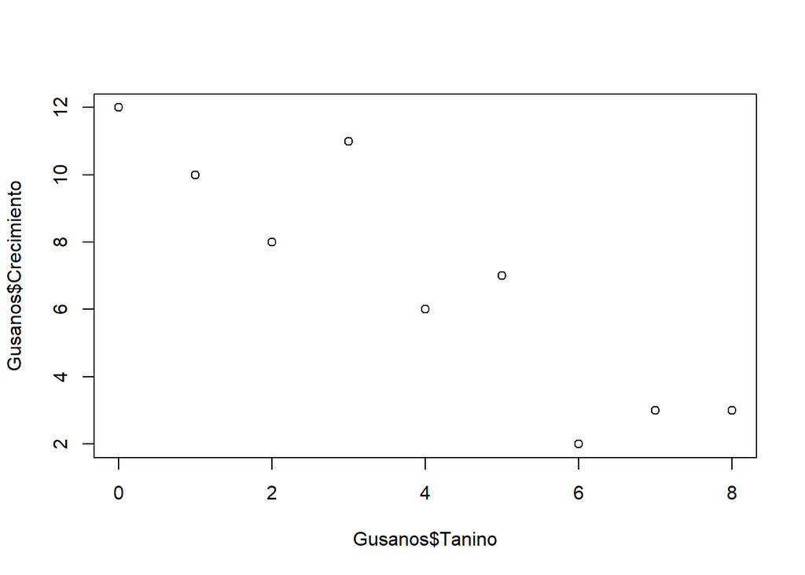

```r
plot(Gusanos$Tanino,Gusanos$Crecimiento)
```

De aquí ya podemos decir más o menos que la $\beta = 12$ más o menos y la pendiente $m$ es de como $−10/8 = −1.25$.

Entonces nuestra aproximación a la ecuación que describe el comportamiento será, como hipótesis,
$$y = 12
− 1.25x$$

Los mínimos cuadrados se refiere a los residuos. Los residuos son la distancia vertical entre los datos y el modelo ajustado. Representan cada una de las distancias del punto a la línea de ajuste. Nuestra medida de ajuste de nuetro modelo matemático, lineal, es la suma de las distancias.

```r
modelo.gusanos <- lm(Gusanos$Crecimiento~Gusanos$Tanino)
```

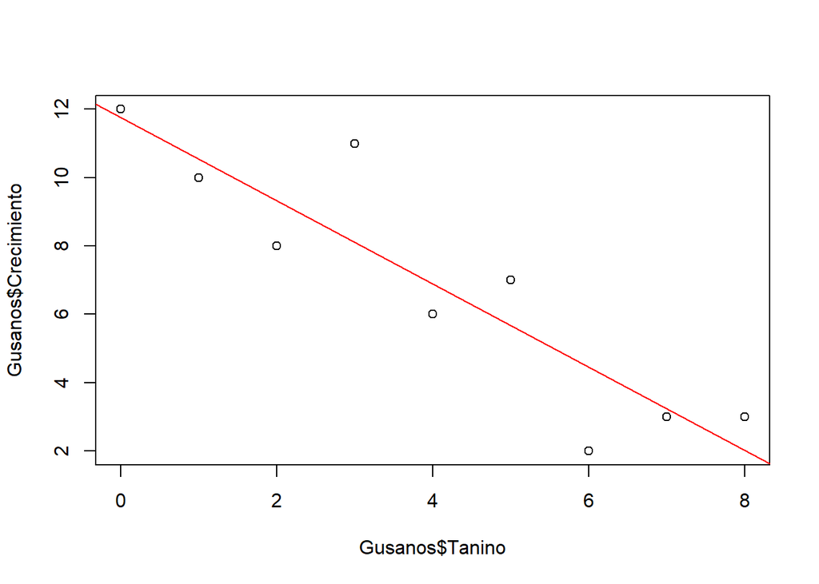

```r
plot(Gusanos$Tanino,Gusanos$Crecimiento)
abline(modelo.gusanos, col="red")
```

Básicamente lo que hace el ajuste es minimizar la suma de las distancias. Para esto necesitamos calcular 5 diferentes valores:

- $\sum{y^{2}}$
- $\sum{y}$
- $\sum{x^{2}}$
- $\sum{x}$
- $\sum{xy}$

De esta forma se pueden hacel los cálculos en **R** con los datos.

```r
suma_de_x <- sum(Gusanos$Tanino)
suma_de_x2 <- sum(Gusanos$Tanino^2)
suma_crec <-sum(Gusanos$Crecimiento)
suma_crec2 <-sum(Gusanos$Crecimiento^2)
suma_x_por_y <- sum(Gusanos$Tanino*Gusanos$Crecimiento)
suma_de_x
```

```
## [1] 36
```

```r
suma_de_x2
```

```
## [1] 204
```

```r
suma_crec
```

```
## [1] 62
```

```r
suma_crec2
```

```
## [1] 536
```

```r
suma_x_por_y
```

```
## [1] 175
```

Ya que tenemos a los 5 valores, éstos se tiene que corregir para los grados de libertad de los datos.

Entonces tenemos que:

Suma de cuadrados de X,
$$SSX =
\sum{x^{2}} - \frac{(\sum{x})^{2}}{n}$$

Suma de cuadrados de Y,
$$SSY =
\sum{y^{2}} - \frac{(\sum{y})^{2}}{n}$$

Suma de productos de XY,
$$SSXY = \sum{xy}
- \frac{(\sum{x})(\sum{y})}{n}$$

```r
n <- nrow(Gusanos)

promedio_x <- mean(Gusanos$Tanino)
promedio_y <- mean(Gusanos$Crecimiento)

sum_cuadrados_x <- suma_de_x2 - ((suma_de_x)^2/n)
sum_cuadrados_y <- suma_crec2 - ((suma_crec)^2/n)
sum_cuadrados_xy <- suma_x_por_y - ((suma_de_x * suma_crec)/n)
sum_cuadrados_x
```

```
## [1] 60
```

```r
sum_cuadrados_y
```

```
## [1] 108.8889
```

```r
sum_cuadrados_xy
```

```
## [1] -73
```

Para para obtener los parámetros de la función.

$$m = \frac{SSXY}{SSX}$$

$$\beta = \frac{\sum{y}}{n} -
m\frac{\sum{x}}{n}$$

```r
pendiente <- sum_cuadrados_xy/sum_cuadrados_x

ordenada <- (suma_crec/n) - (pendiente*(suma_de_x/n))

pendiente
```

```
## [1] -1.216667
```

```r
ordenada
```

```
## [1] 11.75556
```

```r
modelo <- lm(Gusanos$Crecimiento~Gusanos$Tanino)
modelo
```

```
##
## Call:
## lm(formula = Gusanos$Crecimiento ~ Gusanos$Tanino)
##
## Coefficients:
##    (Intercept)  Gusanos$Tanino
##         11.756          -1.217
```

El modelo de regresión despliega diferente información que se utiliza para evaluar el modelo.

```r
summary(modelo)
```

```
##
## Call:
## lm(formula = Gusanos$Crecimiento ~ Gusanos$Tanino)
##
## Residuals:
##     Min      1Q  Median      3Q     Max
## -2.4556 -0.8889 -0.2389  0.9778  2.8944
##
## Coefficients:
##                Estimate Std. Error t value Pr(>|t|)
## (Intercept)     11.7556     1.0408  11.295 9.54e-06 ***
## Gusanos$Tanino  -1.2167     0.2186  -5.565 0.000846 ***
## ---
## Signif. codes:  0 '***' 0.001 '**' 0.01 '*' 0.05 '.' 0.1 ' ' 1
##
## Residual standard error: 1.693 on 7 degrees of freedom
## Multiple R-squared:  0.8157, Adjusted R-squared:  0.7893
## F-statistic: 30.97 on 1 and 7 DF,  p-value: 0.0008461
```

Las priebas de hipótesis de la ordenada al origen y de la pendiente significan si éstas, individualmente, son diferentes de cero. Además, nos da una idea de la fuerza de la regresión por medio de la $R^2$ y si la prueba es estadísticamete significativa por medio del valor de $F$.

### Ejercicios para la regresión

#### **Ejercicio 1**. Gallinas

En un muestreo se obtuvieron los siguientes datos de peso promedio y consumo de alimento de 50 gallinas provenientes de 10 razas. Calcule los valores de la pendiente y la ordenada al origen.

```r
peso.cuerpo <- c(0.6, 1.1,0.8,0.4,1.9,0.7,1.1,1.2,0.9,1.1)
consumo.alimento <-c(87.1,93.1,89.8,91.4,99.5,92.1,95.5,99.3,93.4,94.4)
consumo.alimento
```

```
##  [1] 87.1 93.1 89.8 91.4 99.5 92.1 95.5 99.3 93.4 94.4
```

```r
peso.cuerpo
```

```
##  [1] 0.6 1.1 0.8 0.4 1.9 0.7 1.1 1.2 0.9 1.1
```

Estime para el tamaño de muestra el modelo líneal y una gráfica de regresión.

### Resultado

#### Modelo

```
## [1] 10
```

```
##
## Call:
## lm(formula = peso.cuerpo ~ consumo.alimento)
##
## Residuals:
##      Min       1Q   Median       3Q      Max
## -0.39185 -0.13113 -0.00108  0.15693  0.40259
##
## Coefficients:
##                  Estimate Std. Error t value Pr(>|t|)
## (Intercept)      -7.16969    2.02437  -3.542  0.00760 **
## consumo.alimento  0.08711    0.02162   4.029  0.00379 **
## ---
## Signif. codes:  0 '***' 0.001 '**' 0.01 '*' 0.05 '.' 0.1 ' ' 1
##
## Residual standard error: 0.2518 on 8 degrees of freedom
## Multiple R-squared:  0.6699, Adjusted R-squared:  0.6286
## F-statistic: 16.23 on 1 and 8 DF,  p-value: 0.003794
```

#### Gráfica

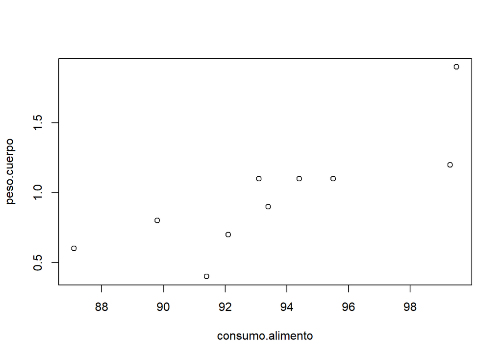

#### Diagnóstico de la regresión con **R**

El diagnóstico incluye:

- Residuales vs. valores estimados (Residuals vs. fitted values)
- Gráfico Q-Q (Q-Q plots)
- Gráfico de escala (Scale Location plots)
- Gráfico de distancia de Cook (Cook’s distance plots).

En el diagnóstico de gráfico de la regresión en **R**, el modelo de regresión es un objeto y se crea un gráfico de dos rengllones y dos columnas (`par(mfrow = c(2,2))`). Se usa la función `plot()` y el modelo se escribe como el argumento.

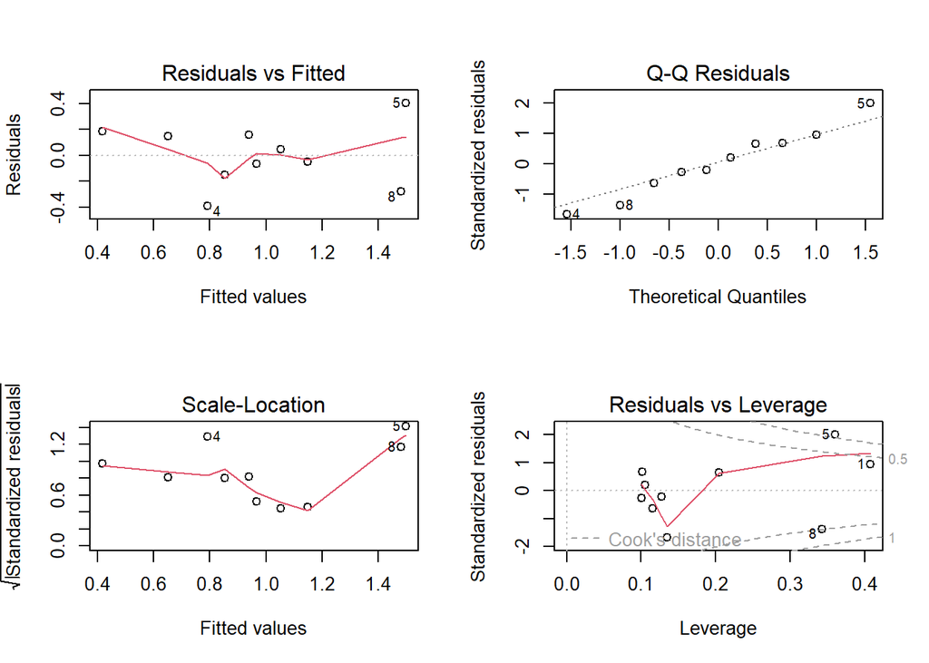

```r
par(mfrow = c(2,2))
plot(modelo.1)
```

```r
par(mfrow = c(1,1))
```

- El primer gráfico (residuales v. valores ajustados) es un gráficos de dispersión entre los residuales y los valores estimados. La dispersión debe ser más o menos aleatoria. Esto es más o menos lo que se ve en el gráfico, recuerde que si tiene valores extremos (outliers) tiene que revisar su información para reconocer el(los) dato(s) extremos.
- El segundo gráfico (normal Q-Q) es la gráfica de la probabilidad normal. Se desplegará una línea recta si los errores se encuentran distribuidos normalmente, vea los puntos que se encuentran fuera de la línea.
- El tercer gráfico (Scale-Location), como el primero, debe de verse aleatorio, no en patrones. El gráfico presenta un pequeño patron en “V” pero en general se puede asumir como aleatorio.
- El 4, último gráfico, (Cook’s distance) nos muestra que puntos tienen la mayor influencia en el modelo de regresión (leverage points). Es importante reconocer y analizar los puntos que tiene mayor influencia en el modelo.

Se puede así tomar la desición de remover o eleiminar algún(os) dato(s) (outlier) si estos han sido mal medidos o estimados y probar como se comporta le modelo. Recuerde que esta ultima actividad tiene que estar justificada por una razón de peso, no es un capricho para mejorar el ajuste del modelo.

#### **Ejercicio 2**. Peso seco en horno (biomasa) y circunferencia de la corona de una muestra de Guayule.

```r
peso.seco <- c(65,100,82,133,133,165,116,120,150,117)
circunferencia <- c(6.5,6.3,5.9,6.3,7.3,8,6.9,8.1,8.7,6.6)
peso.seco
```

```
##  [1]  65 100  82 133 133 165 116 120 150 117
```

```r
circunferencia
```

```
##  [1] 6.5 6.3 5.9 6.3 7.3 8.0 6.9 8.1 8.7 6.6
```

#### Gráfico y Modelo de regresión

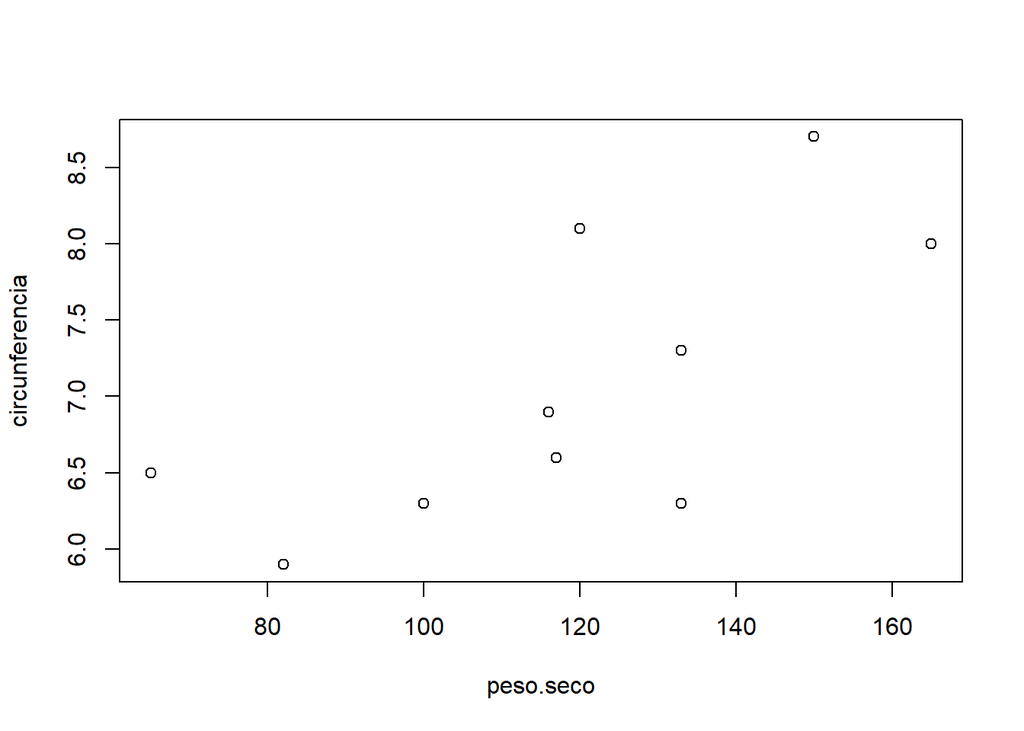

```
##
## Call:
## lm(formula = peso.seco ~ circunferencia)
##
## Residuals:
##     Min      1Q  Median      3Q     Max
## -40.345  -8.623   0.377   9.420  32.210
##
## Coefficients:
##                Estimate Std. Error t value Pr(>|t|)
## (Intercept)     -42.705     57.756  -0.739    0.481
## circunferencia   22.777      8.118   2.806    0.023 *
## ---
## Signif. codes:  0 '***' 0.001 '**' 0.01 '*' 0.05 '.' 0.1 ' ' 1
##
## Residual standard error: 22.62 on 8 degrees of freedom
## Multiple R-squared:  0.496,  Adjusted R-squared:  0.433
## F-statistic: 7.873 on 1 and 8 DF,  p-value: 0.02299
```

#### **Ejercicio 3**. Se condujo un experimento con el fin de estudiar el efecto de un cierto medicamento sobre el ritmo cardiaco de los pacientes.

```r
dosis <- c(0.5,0.75,1,1.25,1.5,1.75,2,2.25,2.5,2.75,3,3.25,3.5)
reduccion.ritmo.cardiaco <- c(10,8,12,12,14,12,16,18,17,20,18,20,21)
dosis
```

```
##  [1] 0.50 0.75 1.00 1.25 1.50 1.75 2.00 2.25 2.50 2.75 3.00 3.25 3.50
```

```r
reduccion.ritmo.cardiaco
```

```
##  [1] 10  8 12 12 14 12 16 18 17 20 18 20 21
```

### Gráfico y modelo de regresión

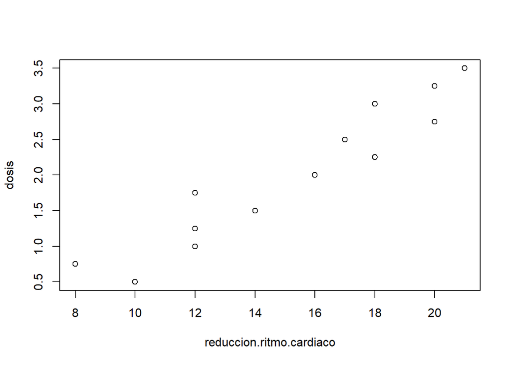

```
##
## Call:
## lm(formula = reduccion.ritmo.cardiaco ~ dosis)
##
## Residuals:
##     Min      1Q  Median      3Q     Max
## -2.2088 -0.3626 -0.1648  0.8571  1.7472
##
## Coefficients:
##             Estimate Std. Error t value Pr(>|t|)
## (Intercept)   7.0549     0.8876   7.949 6.94e-06 ***
## dosis         4.0879     0.4020  10.169 6.25e-07 ***
## ---
## Signif. codes:  0 '***' 0.001 '**' 0.01 '*' 0.05 '.' 0.1 ' ' 1
##
## Residual standard error: 1.356 on 11 degrees of freedom
## Multiple R-squared:  0.9039, Adjusted R-squared:  0.8951
## F-statistic: 103.4 on 1 and 11 DF,  p-value: 6.25e-07
```

#### **Ejercicio 4**. Los siguientes datos muestras las densidades opticas de clorofila dependiendo del nivel de concentración

```r
concentracion <- c(80,120,160,200,240,280,320,360,400,440,480,520)
densidad.optica <- c(0.08,0.12,0.18,0.21,0.28,0.28,0.38,0.4,0.42,0.5,0.52,0.6)
concentracion
```

```
##  [1]  80 120 160 200 240 280 320 360 400 440 480 520
```

```r
densidad.optica
```

```
##  [1] 0.08 0.12 0.18 0.21 0.28 0.28 0.38 0.40 0.42 0.50 0.52 0.60
```

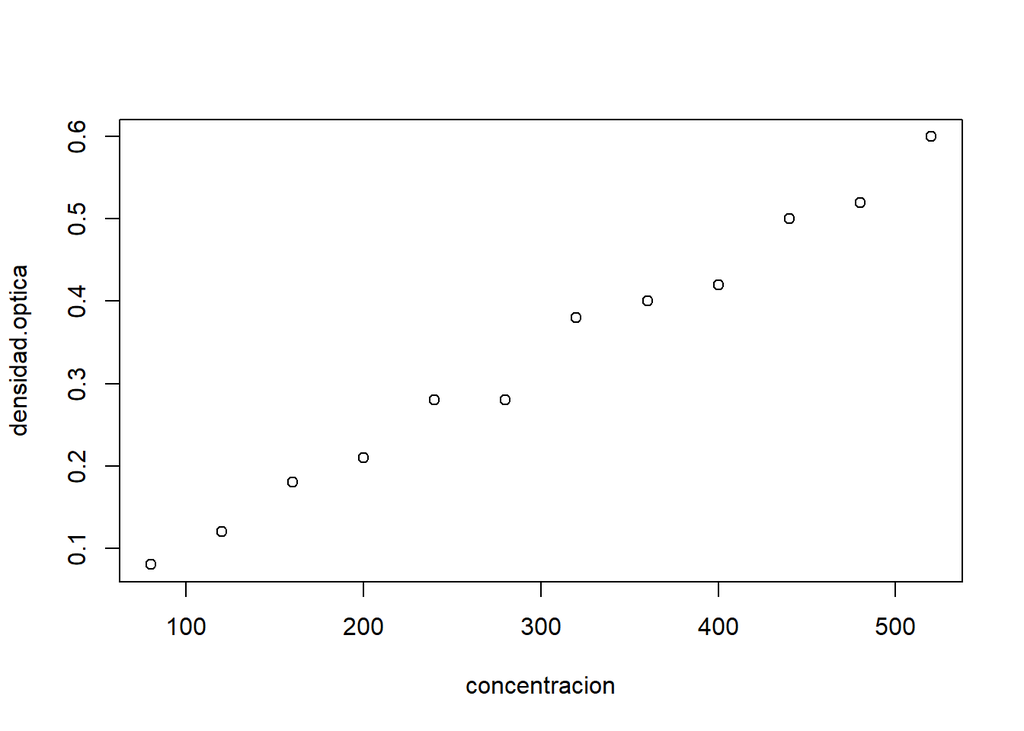

```
##
## Call:
## lm(formula = densidad.optica ~ concentracion)
##
## Residuals:
##        Min         1Q     Median         3Q        Max
## -0.0279837 -0.0090589  0.0005653  0.0113432  0.0263170
##
## Coefficients:
##                 Estimate Std. Error t value Pr(>|t|)
## (Intercept)   -1.191e-02  1.244e-02  -0.957    0.361
## concentracion  1.142e-03  3.767e-05  30.329 3.56e-11 ***
## ---
## Signif. codes:  0 '***' 0.001 '**' 0.01 '*' 0.05 '.' 0.1 ' ' 1
##
## Residual standard error: 0.01802 on 10 degrees of freedom
## Multiple R-squared:  0.9892, Adjusted R-squared:  0.9882
## F-statistic: 919.8 on 1 and 10 DF,  p-value: 3.557e-11
```